# The Hierarchical Meta-Regression

Pablo Emilio Verde

Jun 07 2024

# 1 Introduction

While health researchers may have a simple clinical question, e.g. What is the relative treatment effect of an intervention in a population of interest?, the structure of evidence available to answer it may be very complex. These pieces of evidence could be a combination of published results with different grades of quality, observational studies, or real world data (RWD) in general. Consequentially, statistical models for combining disparate pieces of evidence are of a practical importance.

In this section, we will present recent advances in statistical methods for **cross-design synthesis** and **cross-data synthesis**. These methods have been developed to combine studies with different statistical designs, i.e RCTs with RWD, and with different data types, i.e. aggregated data (AD) and individual participant data (IPD).

These **cross-synthesis** approaches constitute ongoing research, and the aim is to broaden the view of meta-analysis in this complex area. The crucial difference between **cross-synthesis** approaches and other popular approaches to meta-analysis (e.g. random-effects models) is the explicit modeling of internal and external validity bias. Ignoring these types of biases in meta-analysis may lead to misleading conclusions.

# 2 The Hierarchical Meta-Regression

In some situations, we may have IPD from RWD, but relevant results about treatment comparisons from RCTs are only available as a meta-analysis of AD. **Cross-data synthesis** combines IPD from RWD with AD from RCTs. The hope is that by combining multiple types of studies and data we can potentially gain new insights from RCTs’ results, which cannot be seen using only a meta-analysis of RCTs.

The following situation illustrates the aim of the **Hierarchical Meta-Regression** (HMR) model presented in this section: A meta-analysis of RCTs showed efficacy of a new intervention compared to routine clinical practice. Although this kind of meta-analysis is at the top in the hierarchy of clinical-based evidence to prove efficacy, we may be interested in extrapolating RCTs’ results to subgroups of patients that may not meet inclusion criteria (e.g. they may have several comorbidities), but may benefit from this new intervention.

This question about effectiveness in subgroups of patients was called the **empty cell problem** by Droitcour, Silberman, and Chelimsky (1993), where the authors introduced the term **cross-design synthesis**. In the **empty cell problem** we want to assess effectiveness in a subgroup of patients, but those patients do not meet inclusion criteria in RCTs. An schematic representation of the **empty cell problem** is given in the following table:

| Meet inclusion criteria | Study Type RCTs | Study Type OS |
| --- | --- | --- |
| Yes | AD-Data | IPD-RWD |
| No | Empty Cell | IPD-RWD |

The HMR model aims to give an answer to the empty cell problem by combining aggregated data results from RCTs showing efficacy of an intervention and RWD containing IPD of patients that may benefit from this intervention (Verde et al. (2016), Verde (2019)).

On one hand, the idea behind the HMR is to consider the IPD-RWD as representing an **observational control group**, where each subgroup of interest has its own baseline risk. On the other hand, the key regression aspect in the HMR is the potential relationship between baseline risk and efficacy between the AD-RCTs. In this way, given a baseline risk value of a subgroup of patients, we can estimate its corresponding effectiveness. Therefore, the regression model acts as an external validity bias correction for the meta-analysis of RCTs when we are interested in a RWD subgroup.

## 2.1 Modeling pieces of evidence at face value

Consider a meta-analysis of RCTs with binary outcomes, where $y_{1,i}^{(AD)}$ denotes the number of events in the control group of study $i$ ($i=1, \ldots, N$) arising from $n_{1,i}^{(AD)}$ subjects, and $y_{2,i}^{(AD)}$ and $n_{2,i}^{(AD)}$ denote the equivalent quantities in the treatment group.

In addition, we have RWD of patients who have been treated with routine medical care, similarly to the RCT’s control group. We assume that in the RWD the patients’ outcome is the same as in the RCTs. We denote by $y^{(IPD)}_{1, N+1, j}$ (for $j=1, \ldots, M$) the individual participant outcome variable. Moreover, the RWD provides information from several baseline covariates $x_{1,j}, x_{2,j}, \ldots, x_{p,j}$.

We model the outcome variables $y_{1,i}^{(AD)}$, $y_{2,i}^{(AD)}$ and $y^{(IPD)}_{1, N+1, j}$ with the following Binomial distributions:
$$\begin{eqnarray}
y_{1,i}^{(AD)} &\sim& \text{Binomial}(p_{1,i}^{(AD)}, n_{1,i}^{(AD)}), \tag{2.1}\\
y_{2,i}^{(AD)} &\sim& \text{Binomial}(p_{2,i}^{(AD)}, n_{2,i}^{(AD)}), \tag{2.2}\\
y^{(IPD)}_{1, N+1, j} &\sim& \text{Binomial}(p^{(IPD)}_{1, N+1, j}, 1), \tag{2.3}
\end{eqnarray}$$
where $p_{1,i}^{(AD)}$ and $p_{2,i}^{(AD)}$ are the event rates for each treatment group and $p^{(IPD)}_{1, N+1, j} = \text{Pr}\left(y^{(IPD)}_{1, N+1, j} = 1\right)$ the event rate of the IPD-RWD.

Although, in this section we make emphasis in the HMR with dichotomous outcomes, the model can be easily extended e.g. for continues or time to event outcomes.

## 2.2 Random effects and models for biases

The HMR is built upon the combination of several submodels represented by conditional probability distributions. These submodels break down the diversity of data characteristics and the quality of the evidence we aim to combine. We model these aspects of the between-study variability with two correlated random effects:

$$\theta_{1, i} = \text{logit}(p_{1,i}) \tag{2.4}$$
and
$$\theta_{2, i} = \text{logit}(p_{2,i}) - \text{logit}(p_{1,i}), \tag{2.5}$$

where $\text{logit}(p) = \ln(p/(1-p))$. The $\text{logit}(\cdot)$ link is chosen arbitrarily to map probabilities from the (0, 1) interval into the real line. Of course, this is not the only link function that we can apply in HMR, the complementary log-log is an alternative that can be used to model asymmetry.

The random effect $\theta_{1, i}$ represents an **external validity bias** and $\theta_{2, i}$ represents the **relative treatment effect**. The idea of including the random effect $\theta_{1,i}$ is to summarize the number of patients’ characteristics and study design features that may influence the treatment effect $\theta_{2,i}$, but are not directly observed. For this reason we have called $\theta_{1,i}$ the baseline risk effect of study $i$. Independently of the study design, every piece of evidence may suffer from quality performance. Therefore, HMR includes a submodel of study quality bias represented by the random weight $q_i$, where $q_i \sim \chi^2(\nu)$. The idea is to penalize studies with low quality or high risk of bias. In addition, by using a $\chi^2(\nu)$ distribution for the random weights $q_i$ we implicitly defines a marginal t-distribution for the random effects $\theta_1$ and $\theta_2$. This bivariate t-distribution makes the model resistant against outlying results.

The HMR explicitly models the RWD intrinsic bias by a random component $\phi$, which has a mean $\mu_{\phi}$ and a variance $\sigma^2_{\phi} = \sigma_1^2/q_{N+1}$. This intrinsic bias could be the result of a multiplicity of uncontrolled factors such as participant selection bias, errors in measurement of outcomes or information bias, intensity bias in the applications of an intervention and so on.

The HMR model is described by the following system of distributions:

$$\begin{eqnarray}
\theta_{1, i}|q_i &\sim& \text{Normal}\left(\mu_1, \sigma_1^2/q_i \right),\quad (i = 1, 2, \ldots, N) \tag{2.6} \\
\theta_{2, i} | \theta_{1, i}, q_i &\sim&
\text{Normal} \left(\mu_2 - \rho \frac{\sigma_2}{\sigma_1}\, \mu_1 + \rho \frac{\sigma_2}{\sigma_1} (\theta_{1, i}-\mu_1), (1-\rho^2)\sigma_2^2/q_i \right), \tag{2.7} \\
\phi &\sim& \text{Normal}(\mu_{\phi}, \sigma^2_{\phi}), \tag{2.8} \\
\theta_{N+1,1} + \phi|q_{N+1} &\sim& \text{Normal}(\mu_1 + \mu_{\phi} + \beta_1 x_1 + \ldots + \beta_p x_p, \sigma_1^2/q_{N+1}), \tag{2.9}\\
q_i &\sim& \chi^2(\nu), \quad (i = 1, 2, \ldots, N+1) \tag{2.10}.
\end{eqnarray}$$

This regression line has the slope $\sigma_2/\sigma_1 \rho$ and is centered at $\mu_1$. The intercept is $\mu_2 - \rho \frac{\sigma_2}{\sigma_1}\, \mu_1$, which can be interpreted as the treatment effect adjusted by the effect of the baseline risk. If the posterior distribution of $\rho$ is concentrated around zero, the treatment effect is summarized by the posterior of $\mu_2$.

Equations (2.8) - (2.9) represent a bias model for the RWD, which can be constructed as follows: The RWD has a baseline risk with a mean

$$E(\theta_{1, N+1} + \phi) = \mu_1 + \mu_{\phi}.$$

The individual participant characteristics $x_1, x_2, \ldots, x_p$ are used to model risk factors, and to reduce the influence of the **patient selection bias** in the average bias $\mu_{\phi}$:

$$E(\theta_{1, N+1} + \phi |x_1,\ldots, x_p ) = \mu_1 + \mu_{\phi} + \beta_1 x_{1,j} + \ldots + \beta_p x_{p,j} \quad (j = 1, 2,\ldots, M). \quad \tag{2.11}$$

In addition to adjusting for the mean observational bias $\mu_{\phi}$, equation (2.9) connects the baseline effect of the RCTs $\mu_1$ with the effect of the IPD. In a similar way, the parameter $\sigma_1^2$ accounts for the baseline variability across study types. In this context, we call the parameters $\mu_1$ and $\sigma_1^2$ **shared parameters** to highlight that they are estimated across different data and study types.

## 2.3 Assessing effectiveness in subgroups of patients

The HMR model is a specially designed Bayesian approach to assess the effectiveness $\theta_2$ in a subgroup characterized by the risk factor $x_k$ ($k=1,\ldots,p$).

The idea is straightforward: For a baseline risk estimate $\theta_1^k$ representing the subgroup defined by $x_k$, we apply the regression model (2.7) to estimate $\theta_2^k$:
$$\theta_2^k = \alpha_0 + \alpha_1 \, (\theta_1^k - \mu_1),$$
where $\alpha_0 = \mu_2 - \rho \frac{\sigma_2}{\sigma_1}$ and $\alpha_1 =\rho \frac{\sigma_2}{\sigma_1}$. Hence, in principle, the posterior distribution of $\theta_2^k$ is used to infer effectiveness of the subgroup $k$.

The crucial problem of this method is the uncertainty of the location parameter $\theta_1^k$, which involves a partial identified bias correction parameter $\mu_{\phi}$ between the AD-RCTs and the IPD-RWD. We propose the following location for the baseline risk characterized by $x_k$:

$$\theta_1^{k}(B) = \mu_1 + (1-B)\,\mu_{\phi} + \beta_k\, x_k. \tag{2.12}$$

Hence, the effectiveness in a subgroup $k$ is a function of the amount of bias correction $B$ given by

$$\theta_2^k(B) = \alpha_0 + \alpha_1 \, (\theta_1^k(B) - \mu_1). \tag{2.13}$$

It is worth highlighting the following remarks for the location of the baseline risk $\theta_1^k(B)$:

- $B = 0$ the parameter $\mu_1+\mu_{\phi}$ corresponds to the intercept of the logistic regression using the IPD-RWD and $\theta_1^{k}(0) = \mu_1 + \mu_{\phi} + \beta_k \, x_k$. We proposed this approach in Verde et al. (2016), but it has the drawback that no active bias correction is involved by using $\mu_{\phi}$. Therefore, if we expect that a subgroup of frail patients has a baseline risk lower than the mean $\mu_1$, this implies that $|\beta_k| > |\mu_{\phi}|$, which does not necessarily happen for a IPD-RWD.
- Similarly, for $B = 1$ the location $\theta_1^{k}(0)$ centers the IPD-RWD at the mean of RCTs $\mu_1$, which could not reflect the possible baseline risk of a subgroup of frail patients.
- We proposed $B = 2$ in Verde (2019) and we showed by simulations that this location $\theta_1^{k}(2)$ is a good bias correction candidate.
- In Verde et al. (2016) and Verde (2019), we plugged into (2.12) the posterior means of $\mu_1$, $\mu_{\phi}$ and $\beta_k$. This was a pragmatic approach, which clearly underestimates the variability of $\theta_1^k(B)$.

In general, we cannot be certain about the location of the baseline risk $\theta_1^{k}(B)$. Therefore, we proceed by giving a prior distribution to $B$:
$$B \sim \text{Uniform} (B.lower, B.upper),$$
where the range of the Uniform distribution gives the amount of bias correction. In the example below, we use $B.lower = 0$ and $B.upper = 3$, which goes from $\mu_1+\mu_{\phi}$ to $\mu_1-2\,\mu_{\phi}$.

Finally, the join posterior distribution of $\theta_1^{k}(B)$ and $\theta_2^{k}(B)$ is presented to assess effectiveness of the subgroup $k$. We will illustrate this procedure in action in the case study of this section.

## 2.4 Model diagnostic and conflict of evidence

In the HMR model we assess conflict of evidence between the RCTs and the RWD by the posterior distribution of $\mu_{\phi}$, where a posterior concentrated at zero with high probability indicates no conflict between study types. Given that $\mu_{\phi}$ is partially identifiable, a prior-to-posterior sensitivity analysis of $\mu_{\phi}$ to check if the data contains information to estimate its posterior mean.

**A priori**, all studies included have a mean of $E(q_i) = \nu$. We can expect that low quality studies could have a posterior for $q_i$ substantially less than $\nu$. For this reason, the studies’ weights $q_i$ can be interpreted as an adjustment of studies’ **internal validity bias**.

In the HMR framework we define $w_i = \nu /q_i$, where large values of $w_i$ should correspond to outlying studies. In our applications we display the forest plot of the posterior distributions of $w$. This plot can be used to detect studies that are outliers, i.e. studies that could be in conflict with the other studies.

These model diagnostics are implemented in the function diagnostic() in jarbes. The outcome is a plot showing the prior-to-posterior effect in $\mu_{\phi}$, and the forest plot for the $w$’s posteriors.

## 2.5 Priors for hyper-parameters and regression coefficients

We complete the model specification by giving the following set of independent weakly informative priors for the hyperparameters $\mu_1, \mu_2, \mu_{\phi}, \sigma_1, \sigma_2$, $\rho$ and $\nu$. For mean and standard deviation parameters we use:

$$\mu_1, \mu_2, \mu_{\phi} \sim \text{Logistic}(0, 1)$$
and
$$\sigma_1 \sim \text{Uniform}(0, 5), \quad
\sigma_2 \sim \text{Uniform}(0, 5).$$

The priors for the means $\mu_1, \mu_2$, and $\mu_{\phi}$ are non-informative in the sense that in the probability scale, by transforming each mean parameter using $f(x)= \exp(x)/(1+\exp(x))$, they result in uniform distributions between [0, 1].

We chose to use the uniform distributions for the priors of $\sigma_1$ and $\sigma_2$ to weakly constrain the values of these parameters. These priors give equal probabilities within a range between 0 to 5, which includes the case of “non-heterogeneity between studies’ results” to “impossible to combine results”.

The correlation parameter $\rho$ is transformed by using the Fisher transformation,
$$z = \text{logit}\left( \frac{\rho+1}{2} \right)$$
and a Normal prior is used for $z \sim \text{Normal}(0, 1.25)$. This prior is also weakly informative and it centers the prior of $\rho$ scale around 0 with uniform probabilities between [-1, 1].

Using independent priors that constrain $\sigma_1 >0$, $\sigma_2>0$ and $|\rho|<1$ guarantees that in each Markov Chain Monte Carlo (MCMC) iteration the variance-covariance matrix of the random effects $\theta_1$ and $\theta_2$ is positive definite.

In order to have a marginal finite variance of $\theta_1$ and $\theta_2$, the degrees of freedom parameter must be $\nu>2$. We recommend to use $\nu = 4$, which strongly penalizes studies with low quality weights $q_i$ (outlying results) while avoiding infinite marginal variances of $\theta_1$ and $\theta_2$. In this setup, $q_i \sim \chi^2(4)$ with a prior mean of $q_i$ equal to 4, but the probability to have $q_i < 4$ is $59.4\%$, which gives a large chance to observe outliers.

If we combine, i.e. $N >20$ studies, an alternative approach to give a prior for $\nu$ is the following: The $\nu$ parameter is transformed by
$$U = 1/\nu$$
and we give a uniform distribution for $U$:
$$U \sim \text{Uniform}(a, b).$$

For example, candidate values for $a$ and $b$ are $a = 1 / 10$ and $b = 1 / 3$, which allows to explore random-effects distributions that go from a t-distribution with 3 to 10 degrees of freedom. This prior is designed to favor long-tailed distributions and to explore conflict of evidence in meta-analysis.

Priors for regression coefficients act as variable selection procedures, in the HMR we consider the following *hierarchical prior* for the regression coefficients $\beta_1 \ldots \beta_K$:
$$\beta_k \sim \text{Normal}(0, \sigma_{\beta}^2), \quad \sigma_{\beta} \sim \text{Uniform}(0, 5). \tag{2.14}$$
This prior models the coefficients as **exchangeable** with a prior mean equal to zero and unknown variance $\sigma_{\beta}^2$. This prior produces a shrinkage effect toward 0 and it penalizes the inclusion of uninteresting covariates. In general, we have to scale the covariates or use binary covariates in order to make the assumption of **exchangeability** of (2.14) reasonable.

## 2.6 Statistical computations

The posterior distributions of the HMR are calculated with MCMC. We implemented these computations in the R package jarbes (Just a rather Bayesian evidence synthesis) (Verde (2024)). The function hmr() implements the statistical analysis of the HMR, performs model diagnostics, sensitivity analysis of prior-to-posterior, and visualization of results.

The statistical analysis of this section is based on two parallel MCMC simulations with 10,000 iterations for each chain and taks the first 1000 iterations as burn-in period.

# 3 Example: Generalizing RCTs results, a case study in diabetes research

In this example we illustrate the HMR in action by performing a cross-evidence and cross-data synthesis. We fit a HMR to a meta-analysis of AD and a cohort of patients from an IPD-RWD. In the supplementary material of this chapter we provide the R script to run the model and to display the results. The data sets of this example are available in the R package jarbes.

The cohort of IPD-RWD is a set of 260 patients. Some of these patients have similar characteristics to those represented in the RCTs meta-analysis. However, other patients have comorbidities, where one or more risk factors prevent them to participate in the RCTs due to ethical reasons. For example, 118 patients have severe ulcer lesions with a Wagner score 3 and 4, and 77 patients suffer from both, severe ulcer lesions and peripheral arterial disease (PAD). The question is: Can we generalize the benefit observed in the RCTs to the subgroups of patients?

We fitted a HMR model to these data sources by using the function hmr() in jarbes. We start our analysis by visualizing the conflict of evidence between the different types of data and study types. The left panel of Figure 3.1 presents the posterior distribution of $\mu_{\phi}$, which is the mean bias of the IPD-RWD compared to the AD-RCTs control groups. The posterior distribution has a substantial probability mass on the right of zero, which indicates that in average the IPD-RWD patients present a better prognoses than the AD-RCTs control groups. That means that taking the IPD-RWD results at face value would be misleading if we aim to combine them with a meta-analysis of AD-RCTs.

The right panel of Figure 3.1 presents the posterior distribution of the weights $w_{i}$ for each study included in the HMR. These posteriors are summarized using a forest plot, where posterior intervals substantially greater than one indicate outliers. One important aspect of the HMR is that those outliers are automatically down-weighted in the analysis.

```r
#' hmr
#'
set.seed(2022)

hmr.model.1 = hmr(AD,                      # Data frame for Aggregated
           two.by.two = FALSE,      # If TRUE indicates that the trial results are with names: yc, nc, yt, nt
           dataIPD = IPD,           # Data frame of the IPD
           re = "sm",               # Random effects model: "sm" scale mixtures
           link = "logit",          # Link function of the random effects
           sd.mu.1 = 1,             # Scale parameter for the prior of mu.1
           sd.mu.2 = 1,             # Scale parameter for the prior of mu.2
           sd.mu.phi = 1,           # Scale parameter for the prior of mu.phi
           sigma.1.upper = 5,       # Upper bound of the prior of sigma.1
           sigma.2.upper = 5,       # Upper bound of the prior of sigma.2
           sigma.beta.upper = 5,    # Upper bound of the prior of sigma.beta
           sd.Fisher.rho = 1.25,    # Scale parameter for the prior of rho under Fisher's transformation
           df.estimate = TRUE,      # If TRUE the degrees of freedom are estimated
           df.lower = 3,            # Lower bound of the df's prior
           df.upper = 10,           # Upper bound of the df's prior
           nr.chains = 2,           # Number of MCMC chains
           nr.iterations = 10000,   # Total number of iterations
           nr.adapt = 1000,        # Number of iteration discarded for burnin period
           nr.thin = 1)             # Thinning rate
```

```r
summary(hmr.model.1, digits= 2)
```

```
#> Model specification:
#>   Random effects: sm
#>   Link function: logit
#>   Split weights: FALSE
#>   Estimate degrees of freedom: TRUE
#>
#> Fixed effects:
#>                 mean   sd  2.5%   25%   50%   75% 97.5% Rhat n.eff
#> mu.1           -0.56 0.21 -0.96 -0.71 -0.57 -0.43 -0.14    1  1800
#> mu.2            0.66 0.14  0.40  0.57  0.66  0.76  0.95    1  1400
#> intercept       0.59 0.15  0.30  0.48  0.58  0.68  0.90    1   890
#> slope          -0.14 0.14 -0.41 -0.23 -0.14 -0.05  0.15    1   970
#> Odds.pool       1.82 0.28  1.35  1.62  1.78  1.98  2.47    1   840
#> P_control.pool  0.36 0.05  0.28  0.33  0.36  0.40  0.47    1  1900
#>
#> Random effects:
#>          mean   sd  2.5%   25%   50%   75% 97.5% Rhat n.eff
#> sigma.1  1.04 0.20  0.70  0.90  1.02  1.16  1.47    1   730
#> sigma.2  0.53 0.14  0.29  0.43  0.52  0.62  0.86    1  6200
#> rho     -0.27 0.26 -0.71 -0.46 -0.29 -0.10  0.28    1   580
#> df       4.07 1.20  3.02  3.26  3.65  4.44  7.65    1  1100
#>
#> Bias parameters:
#>        mean   sd  2.5%  25%  50%  75% 97.5% Rhat n.eff
#> mu.phi 0.79 1.09 -1.35 0.09 0.78 1.48  2.96    1  5000
#>
#> -------------------
#> Idividual Participant Data Predictors:
#>                          mean   sd  2.5%   25%   50%   75% 97.5% Rhat n.eff
#> sigma.beta               0.64 0.20  0.35  0.51  0.62  0.74  1.08    1 13000
#> beta.PAD                -0.69 0.29 -1.29 -0.88 -0.68 -0.49 -0.14    1 18000
#> beta.neuropathy          0.13 0.35 -0.55 -0.10  0.13  0.36  0.82    1 18000
#> beta.first.ever.lesion  -0.10 0.28 -0.64 -0.28 -0.10  0.09  0.44    1 18000
#> beta.no.continuous.care  0.27 0.28 -0.26  0.09  0.27  0.45  0.82    1  8000
#> beta.male               -0.20 0.30 -0.79 -0.40 -0.20  0.00  0.38    1 18000
#> beta.diab.typ2           0.88 0.44  0.08  0.57  0.86  1.17  1.80    1 18000
#> beta.insulin            -0.10 0.30 -0.70 -0.29 -0.09  0.11  0.49    1 18000
#> beta.HOCHD              -0.05 0.31 -0.67 -0.25 -0.04  0.16  0.57    1  6100
#> beta.HOS                 0.12 0.31 -0.47 -0.09  0.11  0.32  0.73    1 18000
#> beta.CRF                -0.24 0.32 -0.87 -0.45 -0.24 -0.03  0.37    1 18000
#> beta.dialysis           -0.47 0.51 -1.55 -0.78 -0.44 -0.12  0.46    1 18000
#> beta.DNOAP              -0.02 0.38 -0.76 -0.28 -0.02  0.23  0.72    1 18000
#> beta.smoking.ever        0.08 0.29 -0.49 -0.11  0.08  0.27  0.65    1  3900
#> beta.diabdur             0.01 0.02 -0.02  0.00  0.01  0.02  0.05    1 18000
#> beta.wagner.class       -1.41 0.31 -2.03 -1.62 -1.41 -1.20 -0.83    1 18000
#>
#> -------------------
#> MCMC setup (fit using jags): 2 chains, each with 10000 iterations (first 1000 discarded)
#> DIC: 708.16
#> pD: 84.87
```

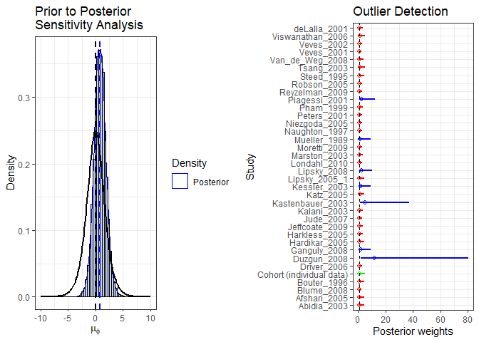

Figure 3.1: Conflict of evidence analysis. Left panel: Prior to posterior sensitivity analysis of bias mean between the RCTs and the IPD-RWD. Right panel: posterior distribution of the outliers detection weights.

```r
# Diagnostic plot
# Analysis of conflict of evidence ................
diagnostic(hmr.model.1, study.names = AD$Study,
    title.plot.mu.phi = "Prior to Posterior\nSensitivity Analysis",
    title.plot.weights = "Outlier Detection",
    post.p.value.cut = 0.1,
           lwd.forest = 1, shape.forest = 1,
    size.forest = 0.4)
```

Figure 3.2 displays the results of the submodel corresponding to the IPD-RWD that received only medical routine care. The posteriors of the regression coefficients $\beta_k$ are summarized in a forest plot. This submodel detects risk factors that can reduce the chance of getting healed. We see that the group of patients with a Wagner score greater than 2 have substantially less chance of getting healed compared to the group with lower scores. This can also be observed in the group of patients with PAD.

Interestingly, these subgroups of patients that have lower chances of getting healed are underrepresented in the RCTs populations. Therefore, by combining IPD-RWD with AD-RCT we can learn new insights about these patients that cannot be learned neither from AD nor from IPD alone.

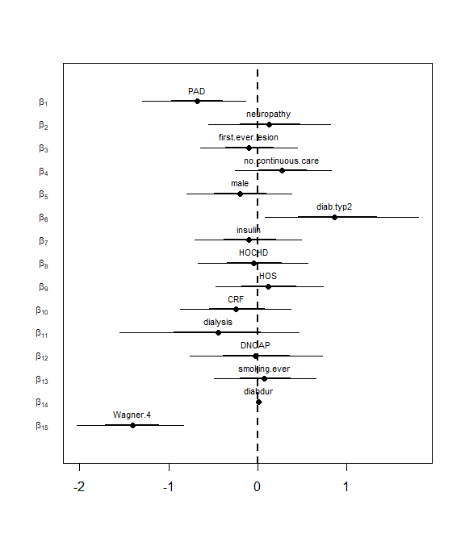

Figure 3.2: Forest plot of posteriors of regression coefficients of the IPD-RWD. The most relevant risk factors identified in this analysis were: the classification of Wagner (1-2 vs. 3-4-5.)and PAD (no vs. yes).

```r
attach.jags(hmr.model.1, overwrite = TRUE)

# Figure: Posterior distribution of the regression coefficients IPD
# Forest plot for the 95% posterior intervals of the regression coefficients

# Variable names
var.names = names(IPD[-1])
var.names = c("PAD", "neuropathy", "first.ever.lesion", "no.continuous.care",
  "male", "diab.typ2", "insulin", "HOCHD", "HOS", "CRF", "dialysis",
  "DNOAP", "smoking.ever", "diabdur", "Wagner.4")

# Coefficient names
v = paste("beta", names(IPD[-1]), sep = ".")

mcmc.x.2 = as.mcmc.rjags(hmr.model.1)

greek.names = paste(paste("beta[",1:15, sep=""),"]", sep="")
par.names = paste(paste("beta.IPD[",1:15, sep=""),"]", sep="")

caterplot(mcmc.x.2,
          parms = par.names,
          col = "black", lty = 1,
          labels = greek.names,
          greek = T,
          labels.loc="axis", cex =0.7,
          style = "plain",reorder = F, denstrip = F)

caterplot(mcmc.x.2,
          parms = par.names,
          col = "black", lty = 1,
          labels = var.names,
          labels.loc="above",
          greek = F,
          cex =0.7,
          style = "plain",reorder = F, denstrip = F,
          add = T)

abline(v=0, lty = 2, lwd = 2)
```

The results of the submodel that correlates the baseline risk with the relative treatment effect are presented in Figure 3.3, where results are displayed in the logit scale. This HMR’s submodel is used to extrapolate treatment effects to subgroups of patients. The posterior median and the 95% posterior intervals show that increasing the healing rate tends to decrease the relative treatment effect. In other words, healthier patients benefit less from the adjunctive therapy.

The model is centered at -0.565, corresponding to the posterior mean of $\mu_1$, the RCTs’ baseline risk. To the right of $\mu_1$ we have the posterior mean of the IPD-RWD $\mu_1 +\mu_{\phi}$, which has a posterior mean of 0.222. This shows an important bias captured by the introduction of $\mu_{\phi}$ in the model.

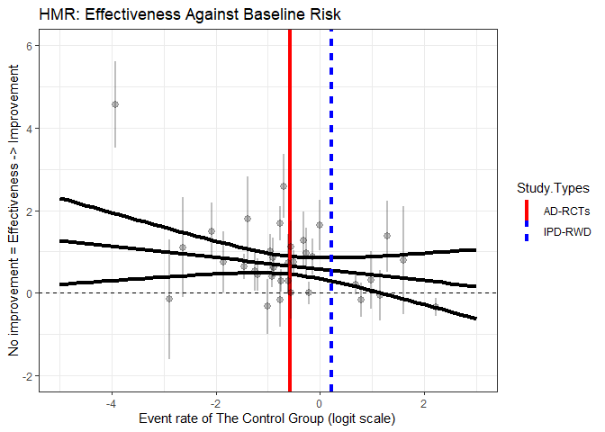

Figure 3.3: Summary results of generalizing relative treatment effects: The RCTs’ results are displayed as a forest plot. The fitted hierarchical meta-regression model is summarized with the solid lines representing the posterior median and 95% intervals. The vertical dashed lines represent the location of the posterior means of the baseline risk for different data and study types.

```r
# Generalization of treatment effects
plot(hmr.model.1,
     x.lim = c(-5, 3),
     y.lim = c(-2, 6),
     x.lab = "Event rate of The Control Group (logit scale)",
     y.lab = "No improvement = Effectiveness -> Improvement",
     title.plot = "HMR: Effectiveness Against Baseline Risk",
     Study.Types = c("AD-RCTs", "IPD-RWD")
     )
```

Figure 3.4 presents the posterior effectiveness contours of $(\theta_1(B), \theta_2(B))$ for the subgroups of patients not included in the RCTs and with low chances of getting healed. On the left panel we have the resulting contour for patients with PAD and on the right panel for patients with Wagner score 3 and 4.

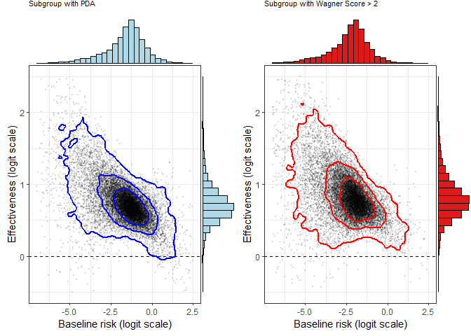

Figure 3.4: Posterior contourns (50%, 75% and 95%) for the effectivenes for subgroups identified in the Hierarchical Meta-Regression analysis. Left panel: Subgroup of patients with PDA. Right panel: Subgroup of patients with Wagner score > 2.

```r
# PDA
p.PDA = effect(hmr.model.1,
       title.plot = "Subgroup with PDA",
       k = 1,            # Regression coefficient
       x.lim = c(-7, 2.5),
       y.lim = c(-.5, 2.5),
       y.lab = "Effectiveness (logit scale)",
       x.lab = "Baseline risk (logit scale)",
       kde2d.n= 150, S = 15000,
       color.line = "blue",
       color.hist = "lightblue",
       font.size.title = 8)

# Wanger
p.Wagner = effect(hmr.model.1,
  title.plot = "Subgroup with Wagner Score > 2",
  k = 15,            # Regression coefficient
  x.lim = c(-7, 2.5),
  y.lim = c(-.5, 2.5),
  y.lab = "Effectiveness (logit scale)",
  x.lab = "Baseline risk (logit scale)",
  kde2d.n= 150, S = 15000,
  color.line = "red",
  color.hist = "#DE1A1A",    #medium red
  display.probability = FALSE,
  line.no.effect = 0,
  font.size.title = 8)

grid.arrange(p.PDA, p.Wagner, ncol = 2, nrow = 1)
```

The effect plot can be presented in the OR against probability scales with the following:

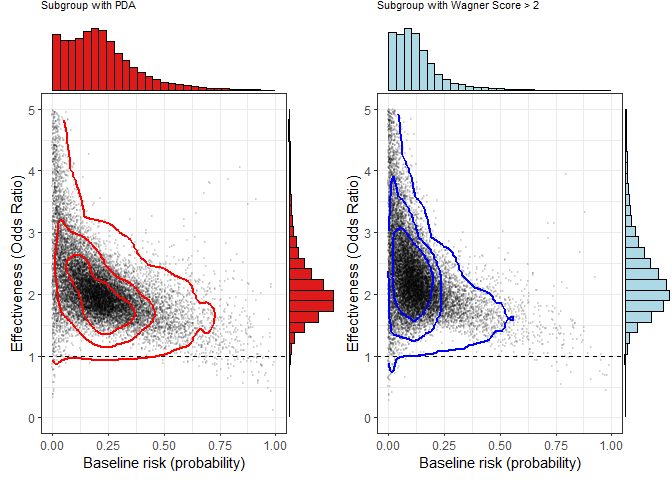

Figure 3.5: Posterior contourns (50%, 75% and 95%) for the effectivenes for subgroups identified in the Hierarchical Meta-Regression analysis. Left panel: Subgroup of patients with PDA. Right panel: Subgroup of patients with Wagner score > 2.

```r
# PDA
p.PDA = effect(hmr.model.1,
       title.plot = "Subgroup with PDA",
       k = 1,            # Regression coefficient
  x.lim = c(0, 1),
  y.lim = c(0, 5),
  y.lab = "Effectiveness (Odds Ratio)",
  x.lab = "Baseline risk (probability)",
  kde2d.n= 150, S = 15000,
  color.line = "red",
  color.hist = "#DE1A1A",    #medium red
  display.probability = TRUE,
  line.no.effect = 1,
  font.size.title = 8)

# Wanger
p.Wagner = effect(hmr.model.1,
  title.plot = "Subgroup with Wagner Score > 2",
  k = 15,            # Regression coefficient
  x.lim = c(0, 1),
  y.lim = c(0, 5),
  y.lab = "Effectiveness (Odds Ratio)",
  x.lab = "Baseline risk (probability)",
  kde2d.n= 150, S = 15000,
  color.line = "blue",
  color.hist = "lightblue",
  display.probability = TRUE,
  line.no.effect = 1,
  font.size.title = 8)

grid.arrange(p.PDA, p.Wagner, ncol = 2, nrow = 1)
```

# References

Clinical Practice at NICE (UK, Centre for, and others). 2011. “Clinical Guideline 119. Diabetic Foot Problems: Inpatient Management of Diabetic Foot Problems.” National Institute for Health; Clinical Excellence.

Droitcour, J, G Silberman, and E Chelimsky. 1993. “Cross-Design Synthesis: A New Form of Meta-Analysis for Combining Results from Randomized Clinical Trials and Medical-Practice Databases.” *International Journal of Technology Assessment in Health Care* 9 (3): 440–49. https://pubmed.ncbi.nlm.nih.gov/8340208/.

Verde, P E. 2019. “The Hierarchical Metaregression Approach and Learning from Clinical Evidence.” *Biometrical Journal* 61 (3): 535–57.

———. 2024. *Jarbes: Just a Rather Bayesian Evidence Synthesis*. https://CRAN.R-project.org/package=jarbes.

Verde, P E, C Ohmann, S Morbach, and A Icks. 2016. “Bayesian Evidence Synthesis for Exploring Generalizability of Treatment Effects: A Case Study of Combining Randomized and Non-Randomized Results in Diabetes.” *Statistics in Medicine* 35 (10): 1654–75.